# R 實作：用圖形與數字描述分布

Week 04 Part 1  
回到 Week 04 Index

HT3001B 生物統計學與 R

2026-10-01

## 完成時間的分布

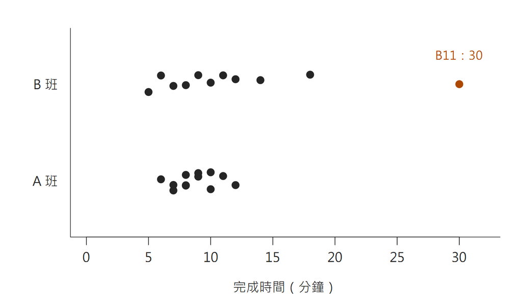

A、B班23筆有效時間，每點一筆；B11為30分鐘。

每點是一筆有效時間。今天用圖形與摘要描述這份資料。

本課程自編虛構完成時間資料

## 資料中的一列代表什麼？

| id | group | completion_min |
| --- | --- | --- |
| A01 | A | 6 |
| A02 | A | 7 |
| B11 | B | 30 |
| B12 | B | NA |

一列是一名虛構學生的一次紀錄。

`completion_min`：分鐘。

遺漏值（missing value）以 `NA` 表示。

班別沒有隨機分派（random assignment）。

本課程自編虛構完成時間資料

## RStudio 的操作區域

[figure not shown]

Posit官方RStudio截圖，標示Source、Console、Environment與Output四個區域。

Source 保存程式；Console 看輸出；Plots 看圖。

[Posit 官方文件](https://docs.posit.co/ide/user/ide/guide/ui/ui-panes.html)；官方介面示意圖，非本班畫面

## Project 內的檔案

```
HT3001B_week04/
├─ week04_tutorial.R
├─ data/
│  └─ week04_completion_times.csv
└─ output/
```

| 檔案 | 用途 |
| --- | --- |
| `.R` | 保存分析步驟 |
| `.csv` | 原始資料或摘要表 |
| `.png` | 輸出圖形 |

資料上傳到 `data/`，程式存於 Project 根目錄。

[Posit Cloud](https://docs.posit.co/cloud/guide/projects/)；本課程檔案配置

## 載入套件與讀取 CSV

```r
library(dplyr)
library(readr)
library(ggplot2)

dat <- read_csv(
  "data/week04_completion_times.csv",
  na = c("", "NA"),
  show_col_types = FALSE
)
```

| 步驟 | 結果 |
| --- | --- |
| `library()` | 本次工作階段載入套件 |
| `read_csv()` | 讀入 CSV |
| `dat` | 資料框（data frame） |

尚未安裝時，先依講義執行 `install.packages()`。

[readr](https://readr.tidyverse.org/reference/read_delim.html)；自編操作例

## 確認欄位與資料列

```r
glimpse(dat)
head(dat)
dat |> count(group)
dat |> filter(is.na(completion_min))
```

| 要確認 | 本例 |
| --- | --- |
| 列 × 欄 | 24 × 3 |
| A／B 班 | 各 12 列 |
| 遺漏時間 | B12：NA |

管線（pipe）`|>` 把前一步結果交給下一個函數。

[readr](https://readr.tidyverse.org/reference/read_delim.html)；本課程自編虛構完成時間資料

## 總列數與有效筆數

```r
dat |>
  summarise(
    n_rows = n(),
    n_observed =
      sum(!is.na(completion_min)),
    n_missing =
      sum(is.na(completion_min))
  )
```

| 總列數 | 有效時間 | 遺漏 |
| --- | --- | --- |
| 24 | 23 | 1 |

摘要時間時，要使用並交代**有效筆數**。

[dplyr](https://dplyr.tidyverse.org/reference/summarise.html)；本課程自編虛構完成時間資料

## 練習｜B 班有幾人？

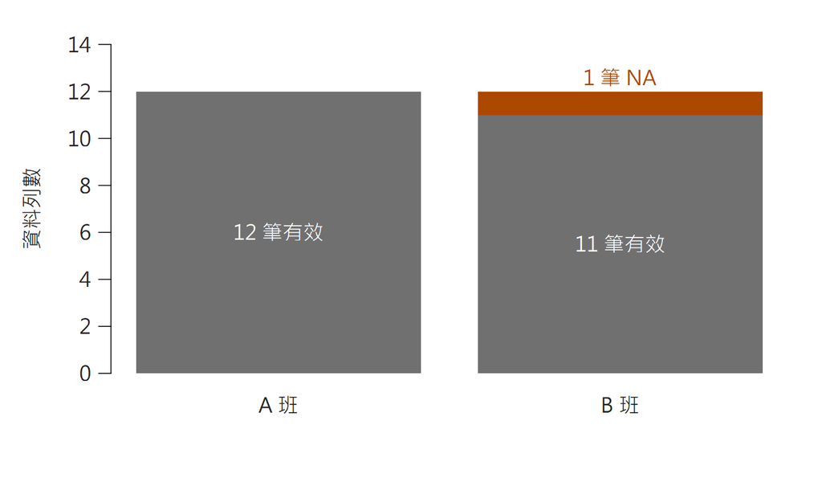

A班12筆有效時間，B班11筆有效時間及1筆遺漏。

B 班的「學生紀錄數」與「有效完成時間數」各是多少？

12 列學生紀錄，11 筆有效時間，另有 1 筆遺漏。

本課程自編虛構完成時間資料

## NA 與 0 的差別

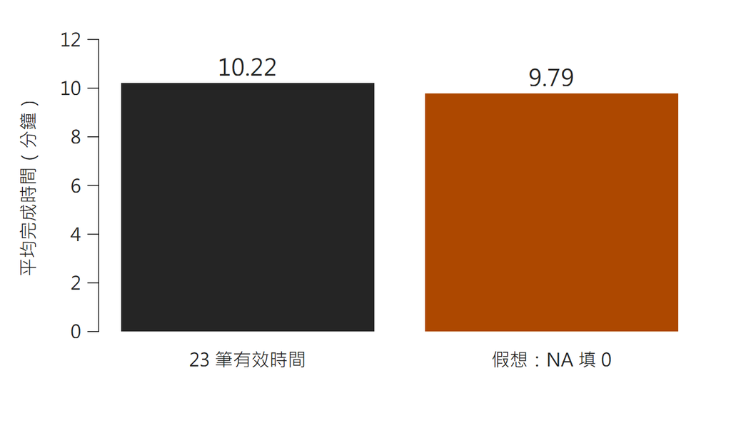

23筆有效值平均10.22分鐘；假想將遺漏填零時平均9.79分鐘。

`NA` 是沒有記錄。0 分鐘會改變資料與平均數。

本課程自編虛構完成時間資料；假想填零比較，原始CSV保留

## 畫圖使用有效時間

```r
dat_observed <- dat |>
  filter(!is.na(completion_min))

ggplot(dat_observed,
       aes(x = completion_min)) +
  geom_histogram(
    binwidth = 5, boundary = 0,
    color = "white", fill = "grey40"
  )
```

| 設定 | 意義 |
| --- | --- |
| `aes(x = ...)` | 指定橫軸變項 |
| `binwidth = 5` | 組距五分鐘 |
| `boundary = 0` | 固定組距邊界起點 |

`+` 接圖層。原始 `dat` 保留。

[ggplot2](https://ggplot2.tidyverse.org/reference/geom_histogram.html)；本課程自編虛構完成時間資料

## 直方圖：時間落在哪裡？

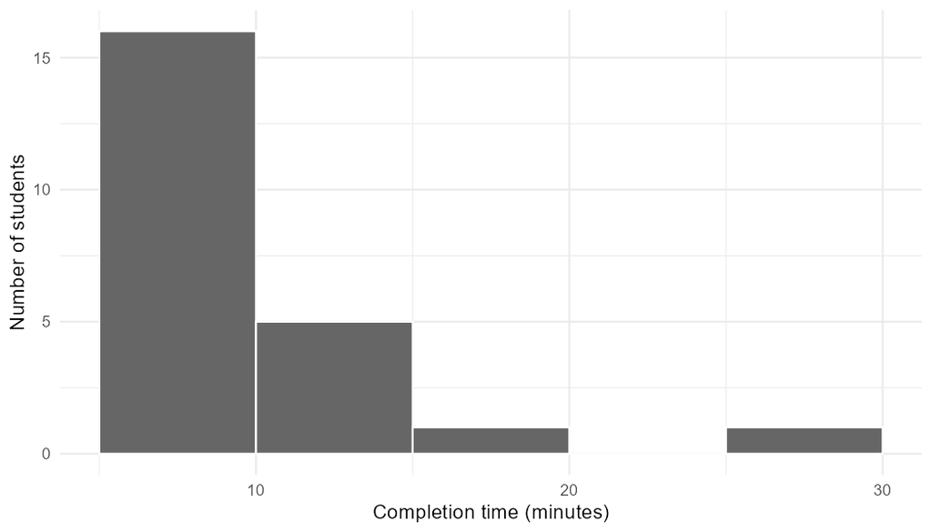

五分鐘組距的完成時間直方圖，23筆有效值，多數在較短時間，30分鐘在右端。

直方圖（histogram）：先看單位、筆數，再看長尾。

本課程自編虛構完成時間資料；IMS §5.3

## 練習｜組距改為兩分鐘

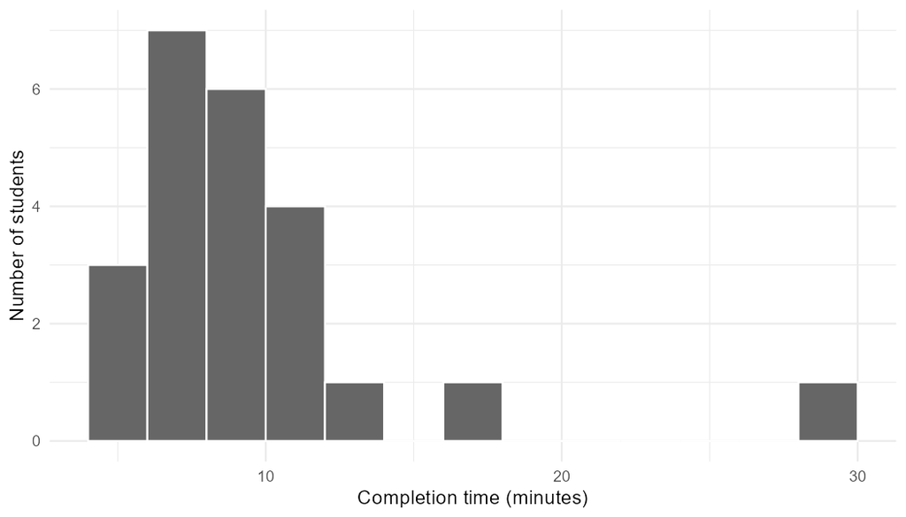

相同23筆時間的兩分鐘組距直方圖，分組更細。

哪些外觀改變？哪些原始資訊保留？

本課程自編虛構完成時間資料；IMS §5.3

## summarise：多列變成一列

```r
summary_all <- dat |>
  summarise(
    mean_min = mean(
      completion_min, na.rm = TRUE),
    median_min = median(
      completion_min, na.rm = TRUE)
  )
summary_all
```

| 平均數（mean） | 中位數（median） |
| --- | --- |
| 10.22 分鐘 | 9 分鐘 |

平均數用全部有效值。

中位數找排序後的中央位置。

[dplyr](https://dplyr.tidyverse.org/reference/summarise.html)；本課程自編虛構完成時間資料

## 平均數與中位數的位置

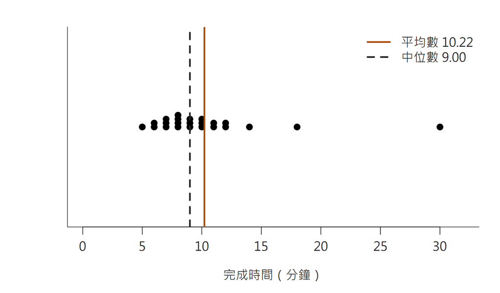

23筆完成時間點圖，平均數10.22分鐘，中位數9分鐘。

右端的較大值會影響平均數。

本課程自編虛構完成時間資料

## SD 與 IQR 描述散布

```r
dat |>
  summarise(
    sd_min = sd(
      completion_min, na.rm = TRUE),
    iqr_min = IQR(
      completion_min,
      na.rm = TRUE, type = 7)
  )
```

| 散布摘要 | 分鐘 |
| --- | --- |
| 標準差（standard deviation，SD） | 5.19 |
| 四分位距（interquartile range，IQR） | 3.50 |

SD 看個別值的散布。

IQR 看中央一半的寬度。

本課程自編虛構完成時間資料；[R sd](https://stat.ethz.ch/R-manual/R-devel/library/stats/html/sd.html)

## 四分位數的位置

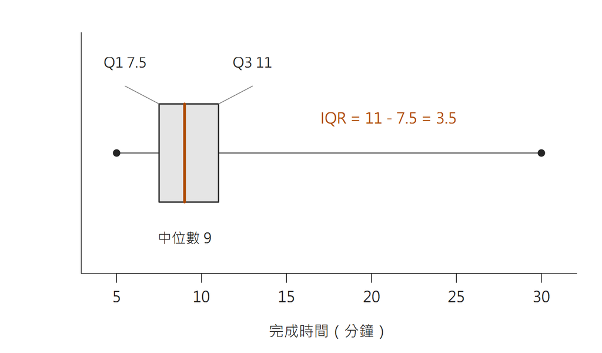

完成時間Q1=7.5、中位數9、Q3=11，IQR為3.5分鐘；線段為最小至最大值。

四分位數（quartiles）：Q1 與 Q3 夾住資料中央約一半。

本課程自編虛構完成時間資料；type = 7；中央區間示意，非盒形圖鬚線

## 練習｜na.rm 改變了什麼？

```r
mean(dat$completion_min)

mean(dat$completion_min,
     na.rm = TRUE)
```

| 程式 | 結果 |
| --- | --- |
| 第一行 | NA |
| 第二行 | 約 10.22 |

兩行結果為什麼不同？

第二行用 23 筆有效值計算。`na.rm = TRUE` 不會補值，也不會消除遺漏偏差。

本課程自編虛構完成時間資料

## group_by：每班各一列

```r
summary_group <- dat |>
  group_by(group) |>
  summarise(
    n_observed = sum(!is.na(completion_min)),
    mean_min = mean(completion_min, na.rm = TRUE),
    median_min = median(completion_min, na.rm = TRUE),
    sd_min = sd(completion_min, na.rm = TRUE),
    iqr_min = IQR(completion_min, na.rm = TRUE),
    .groups = "drop"
  )
summary_group
```

| 班別 | 有效筆數 | 中位數 |
| --- | --- | --- |
| A | 12 | 8.50 |
| B | 11 | 10.00 |

時間單位：分鐘。

`.groups = "drop"` 移除輸出表的分組狀態。

[dplyr](https://dplyr.tidyverse.org/reference/summarise.html)；本課程自編虛構完成時間資料

## 兩班的中心與散布

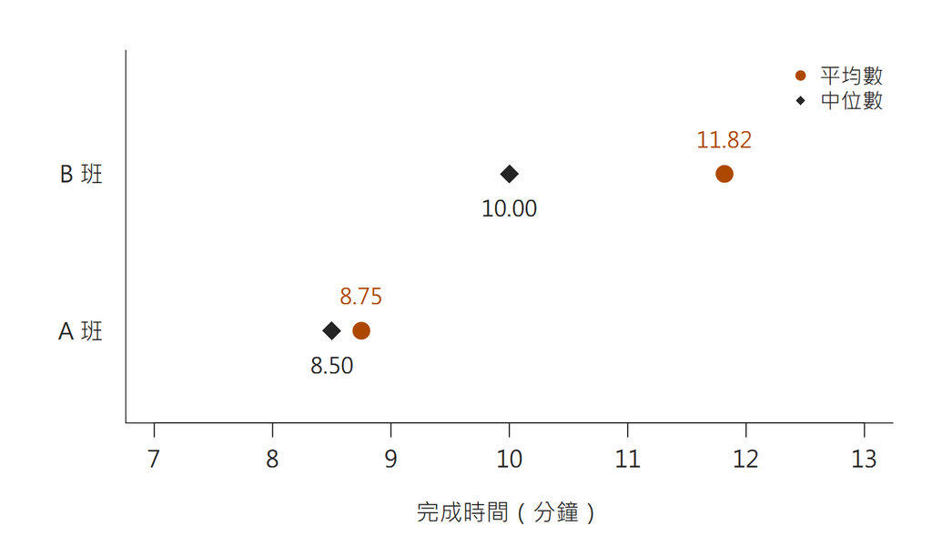

A班平均8.75、中位8.5；B班平均11.82、中位10分鐘。

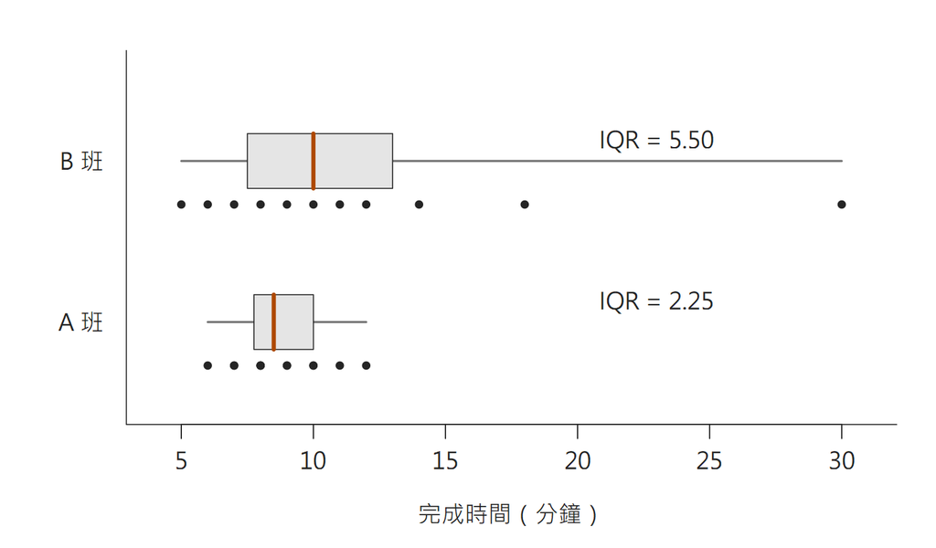

兩班中央區間及原始時間；A班IQR2.25，B班IQR5.5分鐘，線段為min至max。

B 班的中心較高，中央區間也較寬。

本課程自編虛構完成時間資料；四分位區間線段為min至max，非鬚線

## 盒形圖保留每筆資料

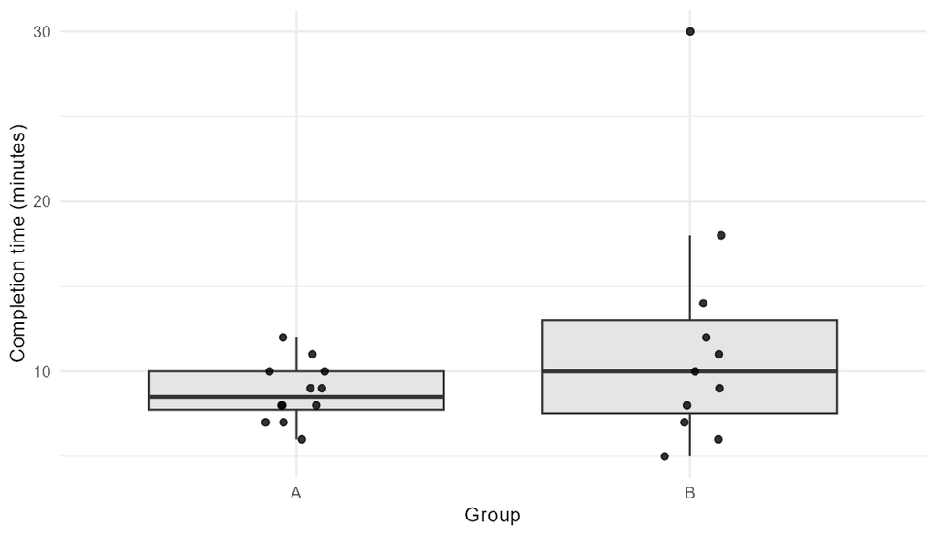

A、B班盒形圖與所有有效觀察點，B班30分鐘點保留。

盒形圖（box plot）：比較中位數與盒長，再查外側點。

本課程自編虛構完成時間資料；IMS §5.5–5.6

## 畫盒形圖與觀察點

```r
p_box <- ggplot(dat_observed,
  aes(x = group, y = completion_min)) +
  geom_boxplot(outlier.shape = NA,
               fill = "grey90") +
  geom_point(position = position_jitter(
    width = 0.08, height = 0, seed = 4))

p_box
```

| 設定 | 資料的狀態 |
| --- | --- |
| `outlier.shape = NA` | 關閉重複的外側點符號 |
| `geom_point()` | 畫出全部有效值 |
| `height = 0` | 時間值不改變 |

原始觀察值沒有刪除。

[ggplot2 boxplot](https://ggplot2.tidyverse.org/reference/geom_boxplot.html)；自編操作例

## 練習｜先查 B11 的紀錄

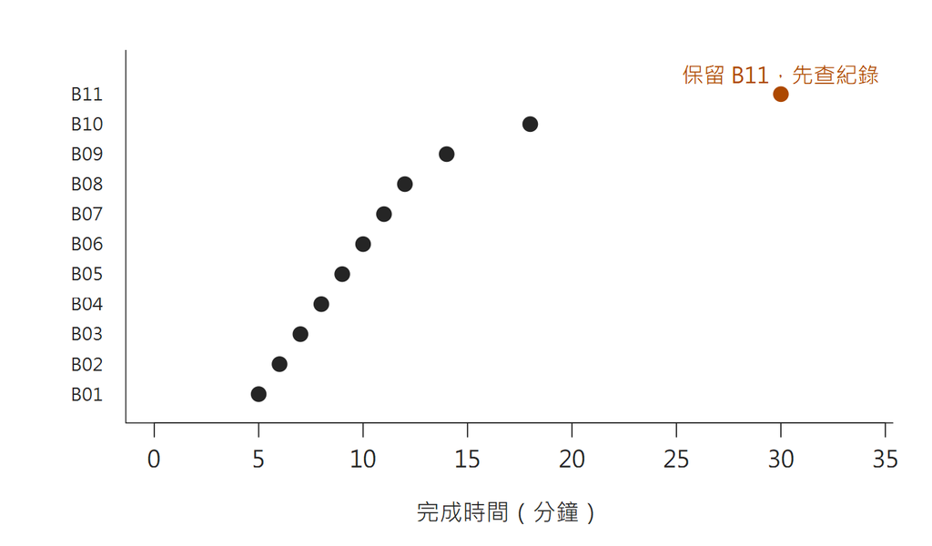

B班每筆有效時間與識別碼，B11的30分鐘標為橘色。

先查原始紀錄、單位與測驗情況。圖上很遠的點，不能直接當成錯誤刪除。

本課程自編虛構完成時間資料

## 保存輸出，重新執行

```r
dir.create("output",
           showWarnings = FALSE)
write_csv(summary_group,
          "output/summary_by_group.csv")
ggsave("output/boxplot.png", p_box,
       width = 7, height = 4, dpi = 150)
```

| 保存的檔案 | 重新取得什麼？ |
| --- | --- |
| `week04_tutorial.R` | 分析步驟 |
| `summary_by_group.csv` | 分組摘要 |
| `boxplot.png` | 分組圖形 |

重新啟動 R，再從第一行執行。

完整程式

本課程自編虛構完成時間資料；自編操作例

## QMD：把說明、程式與結果放在一起

```yaml
---
title: "完成時間分析"
format: html
---
```

檔案開頭的 YAML 設定標題與輸出格式；兩端各有一行 `---`。

`.qmd` 是 Quarto 的文字來源檔，可放入說明、R 程式與執行結果。

1. RStudio：File → New File → Quarto Document，選 HTML。
2. 存成 Project 根目錄的 `week04_report.qmd`。
3. 按 **Render**，產生含文字與結果的 HTML 報告。

[Quarto 官方入門](https://quarto.org/docs/get-started/hello/rstudio.html)；自編操作例

## 用 Markdown 格式化文字

在 QMD 的 **Source** 模式輸入下列語法。

| 寫法 | 呈現效果 |
| --- | --- |
| `# 完成時間分析` | 第一層標題 |
| `## 資料與方法` | 第二層標題 |
| `**有效筆數**` | **有效筆數**：粗體 |
| `*分鐘*` | *分鐘*：斜體 |
| `` `completion_min` `` | `completion_min`：行內程式碼 |
| `- 先確認遺漏值` | 一個項目符號清單項目 |

段落之間留一個空白行；標題的 `#`、清單的 `-` 後留一個空格。

[Quarto Markdown 基礎](https://quarto.org/docs/authoring/markdown-basics.html)；自編操作例

## 在 QMD 嵌入 R 程式碼

````markdown
```{r}
#| echo: true
library(readr)
dat <- read_csv(
  "data/week04_completion_times.csv",
  show_col_types = FALSE
)
mean(dat$completion_min, na.rm = TRUE)
```
````

R 程式碼區塊（code chunk）用三個反引號包住；開頭加 `{r}`。

| 區塊設定 | 效果 |
| --- | --- |
| `#\| echo: true` | 報告顯示程式碼 |
| `#\| echo: false` | 執行，但不顯示程式碼 |
| `#\| eval: false` | 不執行程式碼 |

把範例貼入自己的 QMD 再按 **Render**；所需套件與資料也要在檔內載入。

[Quarto R 區塊](https://quarto.org/docs/get-started/hello/rstudio.html#code-chunks)／[執行設定](https://quarto.org/docs/computations/execution-options.html)；本課程自編虛構資料

## Slido｜Part 1

[**點此開啟 Slido 作答頁 ↗**](https://app.sli.do/event/9DzgBhTDhyRJFR5V1faviF) · 活動代碼 **2612995**

[figure not shown]

[Week04 Slido 活動入口](https://app.sli.do/event/9DzgBhTDhyRJFR5V1faviF)；沿用既有活動